# Definitions

Before hopping into our proof, lets look at a few definitions with some [Geogebra](https://www.geogebra.org/geometry) images.

## Vertical Angles

In class we defined vertical angles as being “across from each other”.

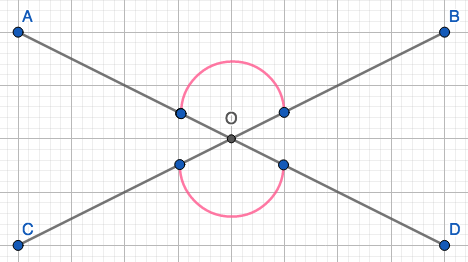

**Fig. 1:** Vertical angles are shown in pink.

We can see a simple example of this in **Fig. 1** where a pair of pink angles $\angle AOB$ and $\angle COD$ are vertical to each other.

Note that $\angle AOC$ and $\angle BOD$ are vertical angles as well.

## Congruence

$x\cong y$ if there is an $\underline{\text{isometry}}$ that superimposes x onto y.

- Isometry is a map that preserves distance and angles
  - translation (move without turning)
  - rotation (moving about a fixed point)
  - reflection (mirror)
  - combination

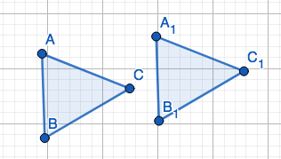

**Fig. 2:** Two congruent triangles

In **Fig. 2** we see the two triangles are congruent, and would only need a translation isometry or two to map $\triangle ABC$ onto $\triangle A_1B_1C_1$.

## Supplementary Angles

We defined supplementary angles as angles whose measurement adds up to $180^\circ$.

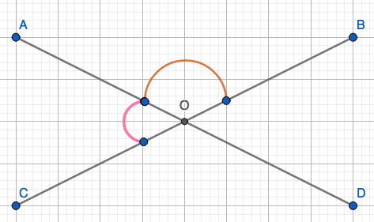

**Fig. 3:** Supplementary angles are shown in pink and orange.

In **Fig.3** we can clearly see that $m\angle AOC$ shown in pink and $m\angle AOB$ in orange adds to a straight line or $180^\circ$. We can also see three other pairs of supplementary angles:

- $m\angle AOB+m\angle BOD=180^\circ$
- $m\angle BOD+m\angle COD=180^\circ$
- $m\angle COD+m\angle AOC=180^\circ$